# Data Scientist for Business NanoDegree

Bruno Italo Lima Benevides

16 de julho de 2018

## 1 - INTRODUCTION

The credit card industry is growing up, around, 15% in the last 10 years in Brazil. And the competition between companys in this sector has grownth as well. Hence, to create competitive advantage is necessary to develop new products to agregate revenue to the credit card’s administrator. But only develop it is not the only way to be better than the others, because a new product may be developed, but no to be a profitable one.

Nowadays brazilian credit card’s companies have a lot of financial services to increase its revenue. One of the most famous is a insurance against losses and theft. In this case the client pays everymonth a certain amount to be assured. That’s only one way to try to rentabilaze the portfolio.

So everytime credit card’s companies are trying to sell its products in too many diferents ways (e.g by chatbots, e-mail marketing, sellers, SMS, etc.). And this study aims to investigate a sale’s channel in particular, SMS, from a credit card’s company that stop to sell a certain product because it was too expensive, not getting a postive margin, never been pais by itself. Then a machine learning model was built to maximize revenue of the firm, through data analysis, that gaves us too many insights about the consumer’s behavior that used to be impactaded by an offer of this product by SMS.

## 2- METHODOLOGY

In a fintech DataBase (DB from now on) that administrate a given credit card, there are a lot of data about the client, features as age, income and many others social, demographic and behavioral data.

So we need a multivariate analysis to identify wich variables affects the probability of client accept or not an offer of the product question of this work. We find here a binary response, because the consumer say `Yes or No` to the offer.

Such that the logistic regression modeling is widely used in cases like this (Susac, Sarlijia and Bensinc, 2004).

# 2.1 - Data Analysis

The dataset is composed by 1.000 clients who had an offer by SMS of a certain product in a credit card’s company. It represents 3.33% of the database wich is really offered in a month. That sample had been chosen because the computational loss for a huge data.

An enterprise in financial enviroment has a lot of client’s features as: gender, limit of credit, age, a behavior score inside the company and too many others. But here there’s only an aim, calculate the probability of a consumer accept an offer of a product in a campaing by SMS, where he just answears ‘Yes or No’ to the simple question: “Do you wanna accep this product in your account? Type Yer or No. For Free”

So as we have a binary independet variable we need to see how some features work with it.

```r
dataset<- read.csv('C:/Users/sony/Downloads/SMS.csv',sep = '\t')
```

Before to see some graph analysis we need to investigate the variables avaible by the company to build the Logistic Regression model.

```r
summary(dataset)
```

```
##      Score             Age          CompanyAge       Limit
##  Min.   :  0.00   Min.   :18.00   Min.   :2.00   Min.   : 150.0
##  1st Qu.: 37.00   1st Qu.:32.00   1st Qu.:3.00   1st Qu.: 240.0
##  Median : 57.00   Median :40.00   Median :4.00   Median : 251.0
##  Mean   : 53.37   Mean   :41.58   Mean   :3.92   Mean   : 365.8
##  3rd Qu.: 71.00   3rd Qu.:51.00   3rd Qu.:5.00   3rd Qu.: 440.0
##  Max.   :100.00   Max.   :80.00   Max.   :5.00   Max.   :2000.0
##      Gender      ExtraCredCard     Accept
##  Min.   :0.000   Min.   :0.0   Min.   :0.000
##  1st Qu.:0.000   1st Qu.:0.0   1st Qu.:0.000
##  Median :1.000   Median :0.0   Median :0.000
##  Mean   :0.702   Mean   :0.1   Mean   :0.412
##  3rd Qu.:1.000   3rd Qu.:0.0   3rd Qu.:1.000
##  Max.   :1.000   Max.   :2.0   Max.   :1.000
```

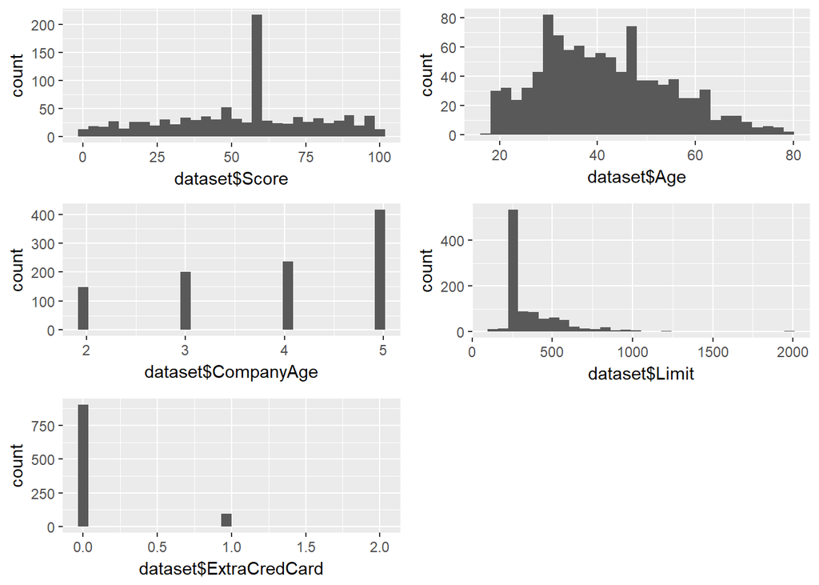

```r
library(ggplot2)
p1 = ggplot(aes(x = dataset$Score), data = dataset) + geom_histogram()
p2 = ggplot(aes(x = dataset$Age), data = dataset) + geom_histogram()
p3 = ggplot(aes(x = dataset$CompanyAge), data = dataset) + geom_histogram()
p4 = ggplot(aes(x = dataset$Limit), data = dataset) + geom_histogram()
p5 = ggplot(aes(x = dataset$ExtraCredCard), data = dataset) + geom_histogram()

library(gridExtra)
grid.arrange(p1,p2,p3,p4,p5, ncol =2)
```

So analysing the relationship between each independent variable and the dependet one using a scatter plot, we can make some assumptions about what we can expect in our logistic model. Our ‘Y Label’ is the data$Accept variable wich has the value 1 if the client had acceptted the product and 0 otherwise.

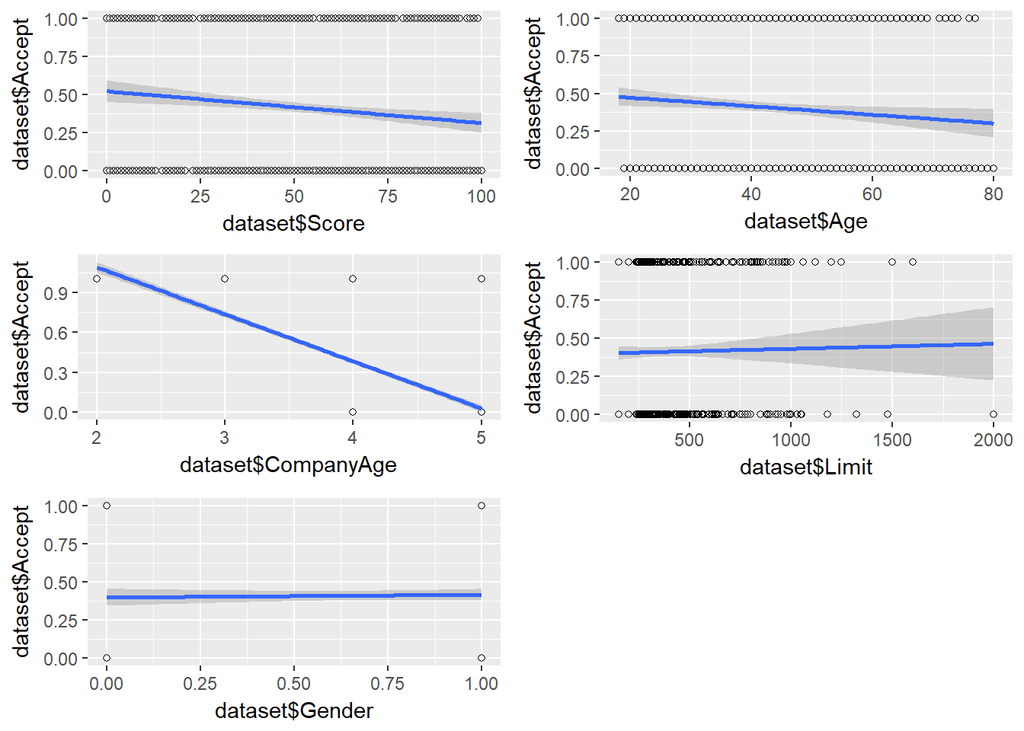

```r
library(ggplot2)

p1 = ggplot(dataset,aes(x = dataset$Score, y = dataset$Accept)) +
  geom_point(shape = 1) +
  geom_smooth(method = lm)

p2 = ggplot(dataset,aes(x = dataset$Age, y = dataset$Accept)) +
  geom_point(shape = 1) +
  geom_smooth(method = lm)

p3 = ggplot(dataset,aes(x = dataset$CompanyAge, y = dataset$Accept)) +
  geom_point(shape = 1) +
  geom_smooth(method = lm)

p4 = ggplot(dataset,aes(x = dataset$Limit, y = dataset$Accept)) +
  geom_point(shape = 1) +
  geom_smooth(method = lm)

p5 = ggplot(dataset,aes(x = dataset$Gender, y = dataset$Accept)) +
  geom_point(shape = 1) +
  geom_smooth(method = lm)

p6 = ggplot(dataset,aes(x = dataset$ExtraCredCard, y = dataset$Accept)) +
  geom_point(shape = 1) +
  geom_smooth(method = lm)


library(gridExtra)

grid.arrange(p1,p2,p3,p4,p5, ncol =2)
```

# 2.1.1 - Multivariate Analysis

```r
library(GGally)
```

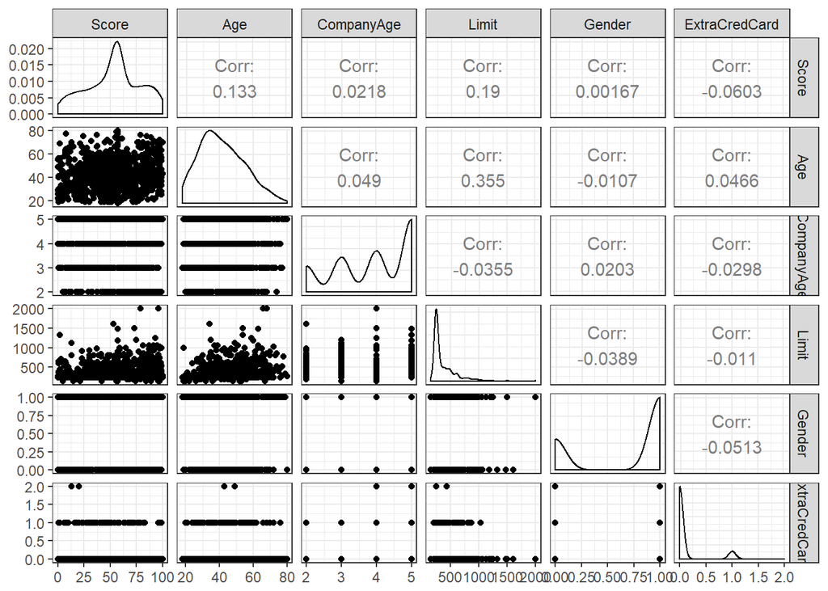

```r
library(ggplot2)
g = ggpairs(dataset[,-7]) + theme_bw()

# Loop through each plot changing relevant scales
for(i in 1:g$nrow) {
  for(j in 1:g$ncol){
    g[i,j] <- g[i,j] +
        scale_fill_manual(values=c("#00AFBB", "#E7B800", "#FC4E07")) +
        scale_color_manual(values=c("#00AFBB", "#E7B800", "#FC4E07"))
  }
}

g
```

# 2.2 - Building the model

Now we gonna start to build the logistic regression model as a classifier to maximize the sales of a certain product in the credit card’s company used in this work.

The first step is to split the dataset into training and test set.

```r
library(caTools)
set.seed(123)
split = sample.split(dataset$Accept, SplitRatio = 0.75)
training_set = subset(dataset,split ==TRUE)
test_set = subset(dataset, split ==FALSE)
```

As we have some binaries independent variables and others are scalars, now we need to do the featuring scallling of the dataset.

```r
training_set[,1:2] = scale(training_set[,1:6])
test_set[,1:2] = scale(test_set[,1:6])
```

Create the classifier is the last step about build a model. After do that we gonna need to analyse the model’s statistics to see if the company will or not use it in a sales action.

```r
classifier = glm(formula = dataset$Accept ~ dataset$Score + dataset$Gender +
                   dataset$CompanyAge,
                    family =  binomial,
                    data = training_set)

summary(classifier)
```

```
##
## Call:
## glm(formula = dataset$Accept ~ dataset$Score + dataset$Gender +
##     dataset$CompanyAge, family = binomial, data = training_set)
##
## Deviance Residuals:
##     Min       1Q   Median       3Q      Max
## -1.2314  -0.3119  -0.2075   0.3579   2.9243
##
## Coefficients:
##                     Estimate Std. Error z value Pr(>|z|)
## (Intercept)        10.685991   0.706974  15.115  < 2e-16 ***
## dataset$Score      -0.014465   0.004453  -3.248  0.00116 **
## dataset$Gender      0.391653   0.239985   1.632  0.10268
## dataset$CompanyAge -2.737871   0.165333 -16.560  < 2e-16 ***
## ---
## Signif. codes:  0 '***' 0.001 '**' 0.01 '*' 0.05 '.' 0.1 ' ' 1
##
## (Dispersion parameter for binomial family taken to be 1)
##
##     Null deviance: 1355.16  on 999  degrees of freedom
## Residual deviance:  557.79  on 996  degrees of freedom
## AIC: 565.79
##
## Number of Fisher Scoring iterations: 6
```

# 3 - Final plots

The graph below shows that the residual distribution has not a normal one. This could be a problem for the model if was used a small number of observations, but with 1.000 there is no problem with this feature of the model.

It’s possible to see, as well, the residual x fitted values. The graph shows us that the model is predicting very well more than 50% of the sample.

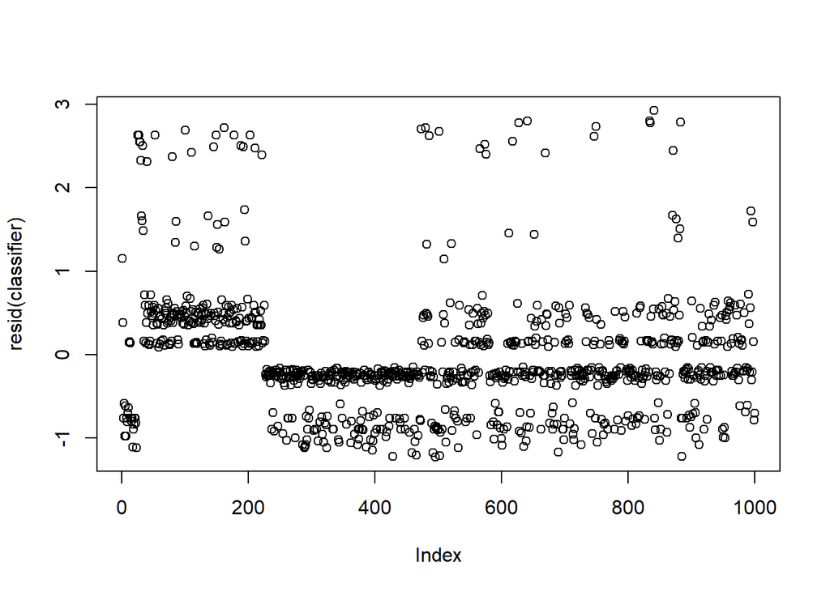

```r
plot(resid(classifier)
)
```

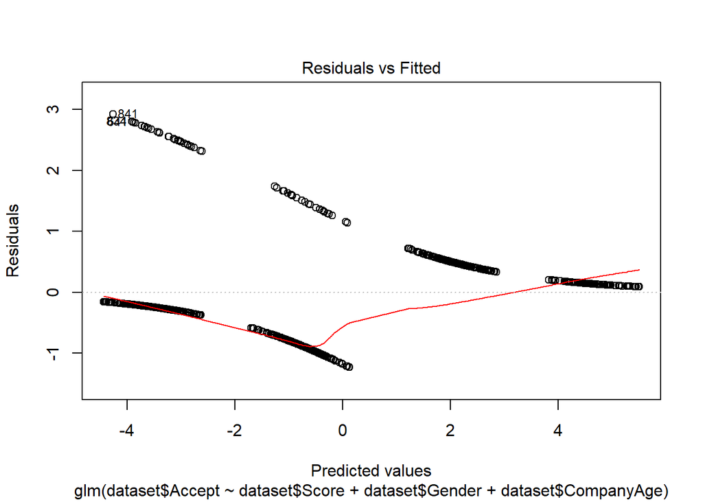

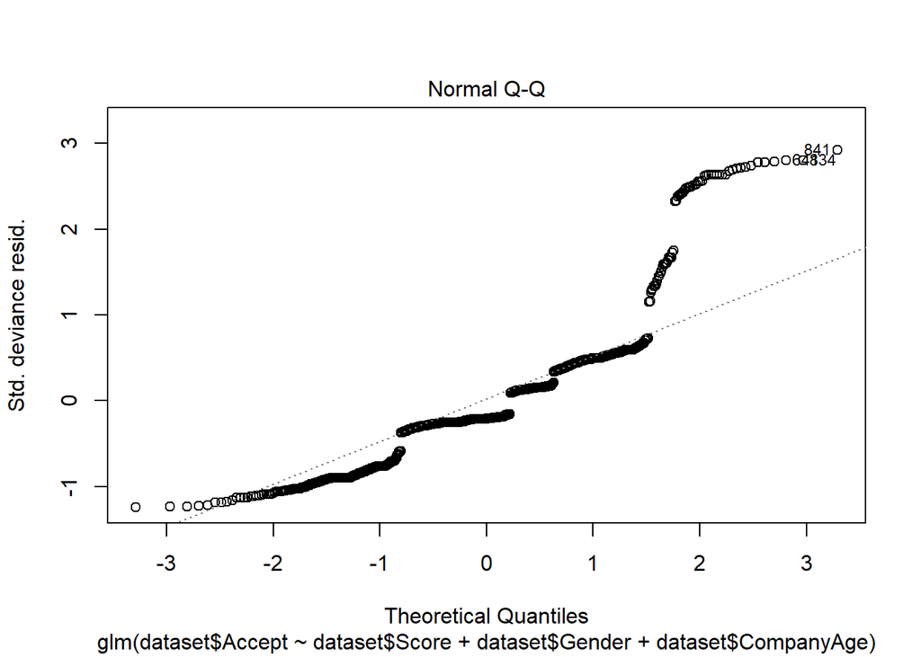

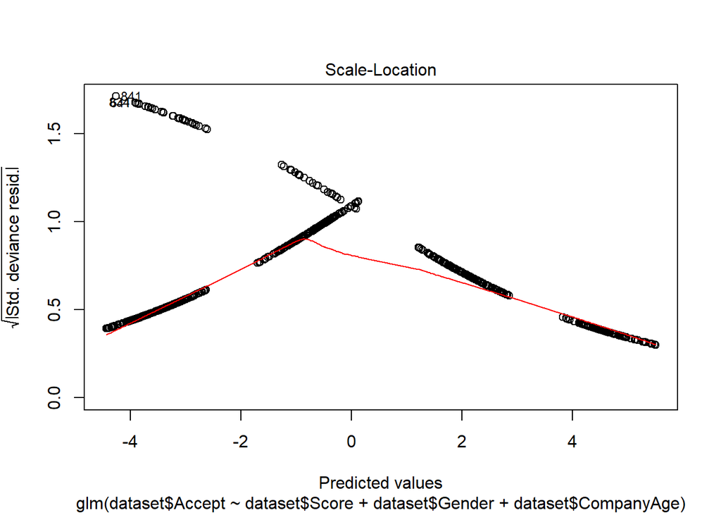

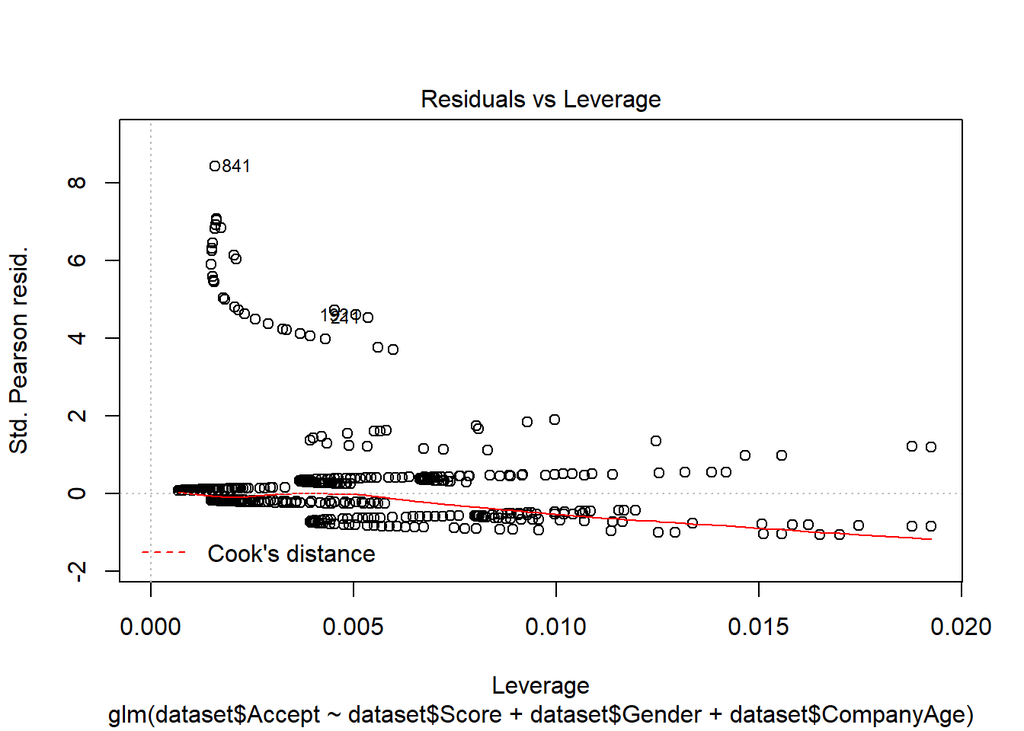

```r
plot(classifier)
```

# 4 - Reflection

Such that the data analysis was possible to build a very good model that predicts the probability of a client with some features buy or not a product ofeered by SMS. After the modelling, the company has gained a cost reductions of 243% per month an increase with this product around 360% per month. That explains the importance to use machine learning, data analysis and data science in a company.

The most difficult part of this project was to organize the dataset, because all of the past SMS campaing were not standarized in a folder. It was a messy in many different folders.

For the next projects is possible to verify the model perfomance in others sales channel, as call center, for exemple. Where the operator, or a bot, could offer the right produc to the right client instantly.